# Assignment Lab Session 3

Shawn Schneidereit

18.11.2020

## **note** that the .Rmd can be found on my [personal repo](https://github.com/schneidereits/Quantitative_Methods_HU/tree/main/assignments) for the corse

### Steps to complete your assignment:

1. Complete the tasks. Write your R code in the designated areas (you can send the code to the console to test your code).
2. Create an HTML file in R-Studio: | Menu | File | Knit Document (alternatively: little Knit button in script header)
3. RENAME your html file to “Assignment_Lab03_YourLastName.html” (replace your last name)
4. Upload your assignment (.html file) to Moodle

### 1. Plotting the airquality dataset (2 points)

Create a scatter-plot showing the relationship between temperature, solar radiation and wind speed. Briefly describe what you see.

```r
airquality <- read_csv("~/Documents/humbolt/quantitative_methods/pc_lab/data/airquality_output.csv")
```

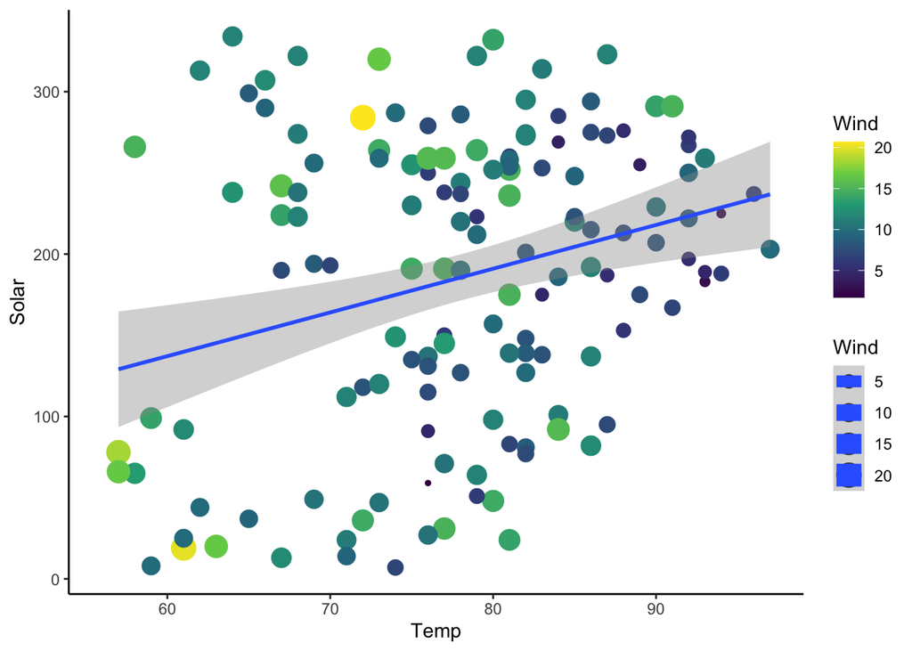

```r
ggplot(airquality, aes(Temp, Solar, color = Wind, size = Wind)) +
  geom_point() +
  stat_smooth(method = lm) + # Add linear regression with trend line to help visualize trend between radiaiton and temp
scale_colour_viridis_c() +
  theme_classic()
```

```r
#In this plot I see that there is a slight visually decernabily positive trend, with large standard error between solar radiation and tempurature. There also seems to be stronger winds at low temperatures and solar radiation also seem to be less variable at higher temperatures than at lower temperatures.
```

Create a scatterplot showing the relationship between ozone concentration and temperature for each month. Briefly describe what you see.

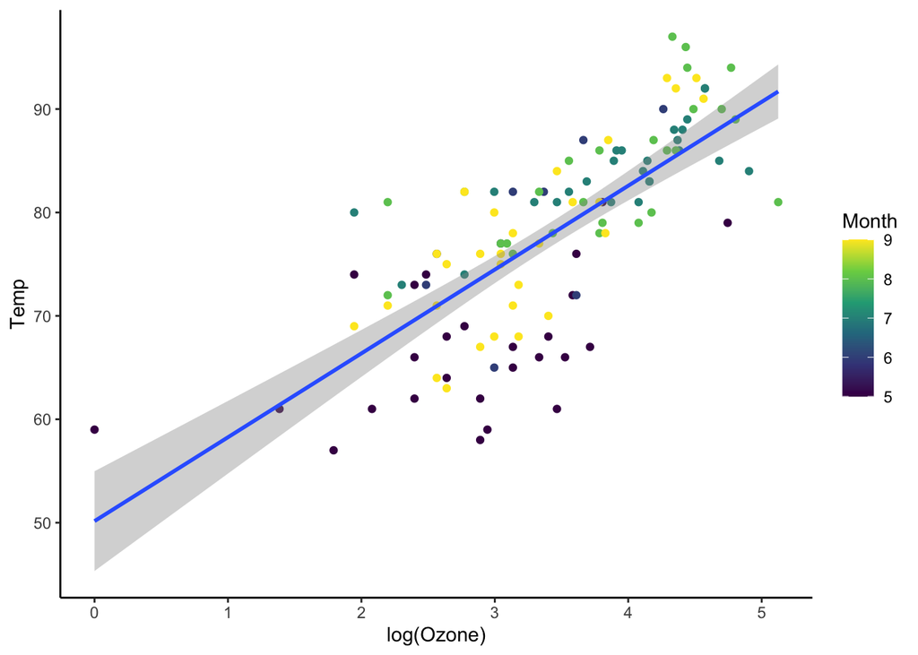

```r
ggplot(airquality, aes(log(Ozone), Temp, color = Month)) +
  geom_point() +
  scale_colour_viridis_c() +
  stat_smooth(method = lm) + # Add linear regression with trend line to help visualize trend between temp and ozone
  theme_classic()
```

```r
# I can see that there is a strong positve trend between tempurate and ozone. note that ozone is on a log transformed scale
# and thus small increases at high tempuratures correspond with portotinally very large increases in measured
# ozone. There is also a trend that summer months (7-8) have both higher temperatures and ozone levels.

# code with month as a factor, but it essentially looks the same, aside from the linear regression being applied individually
# to each month
#ggplot(airquality, aes(log(Ozone), Temp, color = factor(Month))) +
#  geom_point() +
#  scale_colour_viridis_d() +
# stat_smooth(method = lm) +
#  theme_classic()
```

### 2. Wrangel the airquality data (4 points)

Transform the airquality dataset into long-format, with a key column indicating the type of measurement and a value column giving the actual measurements (while keeping the Day, Month, and ID columns).

```r
airquality_long <- gather(airquality, key = measurment, value = )

airquality_long <- airquality %>%
  select(-X1) %>%
    pivot_longer(-(c(1,6:7)), names_to = "measurment", values_to = "value")

head(airquality_long)
```

```
## # A tibble: 6 x 5
##      ID Month   Day measurment value
##   <dbl> <dbl> <dbl> <chr>      <dbl>
## 1     1     5     1 Ozone       41
## 2     1     5     1 Solar      190
## 3     1     5     1 Wind         7.4
## 4     1     5     1 Temp        67
## 5     2     5     2 Ozone       36
## 6     2     5     2 Solar      118
```

Use the transformed dataset to simultaneously visualize the trend of ozone concentration, temperature, wind speed, and solar radiation over time. Hint: The ID column gives you a sequential index of measurement!

```
## notch went outside hinges. Try setting notch=FALSE.
## notch went outside hinges. Try setting notch=FALSE.
## notch went outside hinges. Try setting notch=FALSE.
```

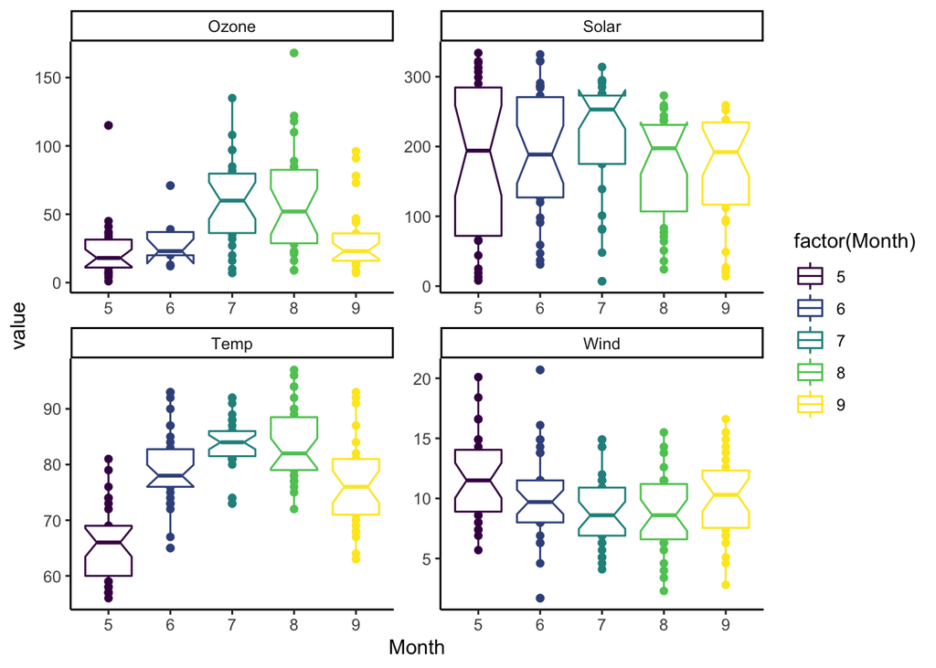

```r
ggplot(airquality_long, aes(Month, value, color = factor(Month))) +
  geom_point() +
   scale_colour_viridis_d() +
  geom_boxplot(notch = T) +
  facet_wrap(.~measurment, scales = "free") +
  theme_classic()
```

### 3. Tree rings (4 points)

Import the dataset ‘treering.csv’. Columns 1 to 56 contain dendrochronological time series of 56 tree cores (annual growth = tree ring widths in mm). Column 57 contains the year associated with the annual tree rings. The dendrochronological time series are of different length, e.g. not all years are observed in each tree core. The column names are the names (ids) of the tree cores.

In Moodle, you’ll find an example plot ‘treering_example.pdf’ showing time series of tree ring widths for each tree core. Create a plot that shows the exact same relationships. Hint: Use the `gather()` function to convert the dataset into the appropriate format!

**NOTE:** In markdown it might be necessary to index the namespace of some functions. In prticular, `dplyr::select()` and `dplyr::filter()` might fail knitting if the namespace is not defined.

```r
treering <- read_csv("~/Documents/humbolt/quantitative_methods/pc_lab/data/treering.csv")
```

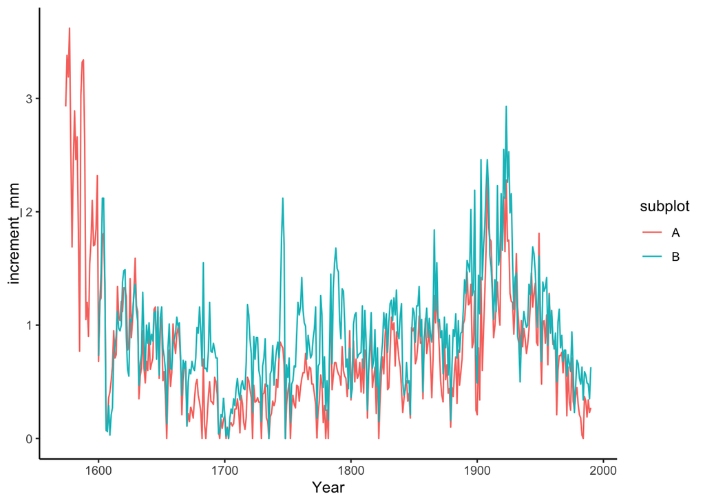

```r
treering_long <- treering %>%
  gather(key = ID, value = increment_mm, 1:56) %>%
  drop_na() %>%
  mutate(subplot = if_else(grepl("A", ID), "A", "B")) %>%  # if ID string contains A then subplot = A, else B
  dplyr::filter(grepl("40", ID)) # filter ID for rows that contain 40


ggplot(treering_long, aes(Year, increment_mm, group = subplot, color = subplot)) +
  geom_line() +
  theme_classic()
```

Following, calculate the mean and standard deviation of increment for each dendrochronological time series. Hint: Use a combination of `group_by()` and `summarize()` available through the **dplyr** package. Prove your solution by showing the first 5 rows of the summary dataset!

```r
# same wrangling expect data is not filtered for plot 40
treering_sum <- treering %>%
  gather(key = ID, value = increment_mm, 1:56) %>%
  drop_na() %>%
  mutate(subplot = if_else(grepl("A", ID), "A", "B")) %>%
  group_by(ID) %>%
  summarise(mean = mean(increment_mm),
            sd = sd(increment_mm))

head(treering_sum)
```

```
## # A tibble: 6 x 3
##   ID      mean    sd
##   <chr>  <dbl> <dbl>
## 1 X_03_A 0.580 0.308
## 2 X_03_B 0.717 0.470
## 3 X_05_A 0.917 0.442
## 4 X_05_B 0.923 0.657
## 5 X_07_A 0.576 0.291
## 6 X_07_B 0.908 0.509
```

Which plot has the highest/lowest increment?

```r
treering_sum %>% arrange(-mean) %>%
  slice(1) # highest increment, plot X-50_A with 2.04
```

```
## # A tibble: 1 x 3
##   ID      mean    sd
##   <chr>  <dbl> <dbl>
## 1 X_50_A  2.05  1.05
```

```r
treering_sum %>% arrange(mean) %>% # lowest increment, plot X_14_A with 0.48
  slice(1)
```

```
## # A tibble: 1 x 3
##   ID      mean    sd
##   <chr>  <dbl> <dbl>
## 1 X_14_A 0.481 0.232
```